# Exercise 3

Adam Lu

2018/03/10

First, import libraries

```r
library(readr)
library(dplyr)
library(ggplot2)
```

Next, import the [National Health and Nutrition Examination Survey data](https://www.cdc.gov/nchs/nhanes/index.htm)

```r
nh <- read_csv("../data/nhanes.csv")
nh
```

```
## # A tibble: 5,000 x 32
##       id Gender   Age Race    Education    MaritalStatus RelationshipStat~
##    <int> <chr>  <int> <chr>   <chr>        <chr>         <chr>
##  1 62163 male      14 Asian   <NA>         <NA>          <NA>
##  2 62172 female    43 Black   High School  NeverMarried  Single
##  3 62174 male      80 White   College Grad Married       Committed
##  4 62174 male      80 White   College Grad Married       Committed
##  5 62175 male       5 White   <NA>         <NA>          <NA>
##  6 62176 female    34 White   College Grad Married       Committed
##  7 62178 male      80 White   High School  Widowed       Single
##  8 62180 male      35 White   College Grad Married       Committed
##  9 62186 female    17 Black   <NA>         <NA>          <NA>
## 10 62190 female    15 Mexican <NA>         <NA>          <NA>
## # ... with 4,990 more rows, and 25 more variables: Insured <chr>,
## #   Income <int>, Poverty <dbl>, HomeRooms <int>, HomeOwn <chr>,
## #   Work <chr>, Weight <dbl>, Height <dbl>, BMI <dbl>, Pulse <int>,
## #   BPSys <int>, BPDia <int>, Testosterone <dbl>, HDLChol <dbl>,
## #   TotChol <dbl>, Diabetes <chr>, DiabetesAge <int>, nPregnancies <int>,
## #   nBabies <int>, SleepHrsNight <int>, PhysActive <chr>,
## #   PhysActiveDays <int>, AlcoholDay <int>, AlcoholYear <int>,
## #   SmokingStatus <chr>
```

Change all character data types to the “factor” data type

```r
nh <- nh %>%
    mutate_if(is.character, as.factor)
nh
```

```
## # A tibble: 5,000 x 32
##       id Gender   Age Race    Education    MaritalStatus RelationshipStat~
##    <int> <fct>  <int> <fct>   <fct>        <fct>         <fct>
##  1 62163 male      14 Asian   <NA>         <NA>          <NA>
##  2 62172 female    43 Black   High School  NeverMarried  Single
##  3 62174 male      80 White   College Grad Married       Committed
##  4 62174 male      80 White   College Grad Married       Committed
##  5 62175 male       5 White   <NA>         <NA>          <NA>
##  6 62176 female    34 White   College Grad Married       Committed
##  7 62178 male      80 White   High School  Widowed       Single
##  8 62180 male      35 White   College Grad Married       Committed
##  9 62186 female    17 Black   <NA>         <NA>          <NA>
## 10 62190 female    15 Mexican <NA>         <NA>          <NA>
## # ... with 4,990 more rows, and 25 more variables: Insured <fct>,
## #   Income <int>, Poverty <dbl>, HomeRooms <int>, HomeOwn <fct>,
## #   Work <fct>, Weight <dbl>, Height <dbl>, BMI <dbl>, Pulse <int>,
## #   BPSys <int>, BPDia <int>, Testosterone <dbl>, HDLChol <dbl>,
## #   TotChol <dbl>, Diabetes <fct>, DiabetesAge <int>, nPregnancies <int>,
## #   nBabies <int>, SleepHrsNight <int>, PhysActive <fct>,
## #   PhysActiveDays <int>, AlcoholDay <int>, AlcoholYear <int>,
## #   SmokingStatus <fct>
```

Filter the data to include adults only

```r
nha <- nh %>% filter(Age >= 18)
nha
```

```
## # A tibble: 3,707 x 32
##       id Gender   Age Race  Education    MaritalStatus RelationshipStatus
##    <int> <fct>  <int> <fct> <fct>        <fct>         <fct>
##  1 62172 female    43 Black High School  NeverMarried  Single
##  2 62174 male      80 White College Grad Married       Committed
##  3 62174 male      80 White College Grad Married       Committed
##  4 62176 female    34 White College Grad Married       Committed
##  5 62178 male      80 White High School  Widowed       Single
##  6 62180 male      35 White College Grad Married       Committed
##  7 62199 male      57 White College Grad LivePartner   Committed
##  8 62199 male      57 White College Grad LivePartner   Committed
##  9 62199 male      57 White College Grad LivePartner   Committed
## 10 62199 male      57 White College Grad LivePartner   Committed
## # ... with 3,697 more rows, and 25 more variables: Insured <fct>,
## #   Income <int>, Poverty <dbl>, HomeRooms <int>, HomeOwn <fct>,
## #   Work <fct>, Weight <dbl>, Height <dbl>, BMI <dbl>, Pulse <int>,
## #   BPSys <int>, BPDia <int>, Testosterone <dbl>, HDLChol <dbl>,
## #   TotChol <dbl>, Diabetes <fct>, DiabetesAge <int>, nPregnancies <int>,
## #   nBabies <int>, SleepHrsNight <int>, PhysActive <fct>,
## #   PhysActiveDays <int>, AlcoholDay <int>, AlcoholYear <int>,
## #   SmokingStatus <fct>
```

1. What’s the relationship between diabetes and participating in rigorous physical activity or sports?
- Create a contingency table with Diabetes status in rows and physical activity status in columns.

```r
xt <- xtabs(~ Diabetes + PhysActive, data = nha)
xt
```

```
##         PhysActive
## Diabetes   No  Yes
##      No  1462 1883
##      Yes  230  132
```

- Display that table with margins.

```r
addmargins(xt)
```

```
##         PhysActive
## Diabetes   No  Yes  Sum
##      No  1462 1883 3345
##      Yes  230  132  362
##      Sum 1692 2015 3707
```

- Show the proportions of diabetics and nondiabetics, separately, who are physically active or not.

```r
prop.table(xt, margin = 1)
```

```
##         PhysActive
## Diabetes        No       Yes
##      No  0.4370703 0.5629297
##      Yes 0.6353591 0.3646409
```

- Is this relationship significant?

```r
# Use the Pearson's Chi-squared test with Yates' continuity correction
chisq.test(xt)
```

```
##
##  Pearson's Chi-squared test with Yates' continuity correction
##
## data:  xt
## X-squared = 50.97, df = 1, p-value = 9.377e-13
```

```r
# Fisher's Exact Test for Count Data
# https://en.wikipedia.org/wiki/Fisher%27s_exact_test
fisher.test(xt)
```

```
##
##  Fisher's Exact Test for Count Data
##
## data:  xt
## p-value = 7.239e-13
## alternative hypothesis: true odds ratio is not equal to 1
## 95 percent confidence interval:
##  0.3531418 0.5607432
## sample estimates:
## odds ratio
##  0.4456921
```

- Create a mosaic plot to visualize the relationship.

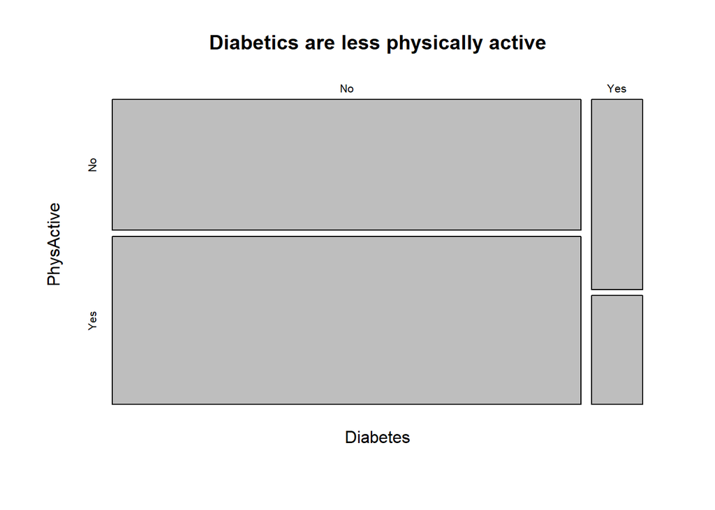

```r
mosaicplot(xt, main = "Diabetics are less physically active")
```

2. Model the same association in a logistic regression framework to assess the risk of diabetes using physical activity as a predictor.
- Fit a model with just physical activity as a predictor, and display a model summary.

```r
fit <- glm(Diabetes ~ PhysActive, data = nha, family = "binomial")
summary(fit)
```

```
##
## Call:
## glm(formula = Diabetes ~ PhysActive, family = "binomial", data = nha)
##
## Deviance Residuals:
##     Min       1Q   Median       3Q      Max
## -0.5406  -0.5406  -0.3681  -0.3681   2.3348
##
## Coefficients:
##               Estimate Std. Error z value Pr(>|z|)
## (Intercept)   -1.84948    0.07094 -26.073  < 2e-16 ***
## PhysActiveYes -0.80834    0.11462  -7.052 1.76e-12 ***
## ---
## Signif. codes:  0 '***' 0.001 '**' 0.01 '*' 0.05 '.' 0.1 ' ' 1
##
## (Dispersion parameter for binomial family taken to be 1)
##
##     Null deviance: 2371.7  on 3706  degrees of freedom
## Residual deviance: 2319.9  on 3705  degrees of freedom
## AIC: 2323.9
##
## Number of Fisher Scoring iterations: 5
```

- Add gender to the model, and show a summary.

```r
fit <- glm(Diabetes ~ PhysActive + Gender, data = nha, family = "binomial")
summary(fit)
```

```
##
## Call:
## glm(formula = Diabetes ~ PhysActive + Gender, family = "binomial",
##     data = nha)
##
## Deviance Residuals:
##     Min       1Q   Median       3Q      Max
## -0.5686  -0.5123  -0.3874  -0.3476   2.3820
##
## Coefficients:
##               Estimate Std. Error z value Pr(>|z|)
## (Intercept)   -1.96460    0.09277 -21.177  < 2e-16 ***
## PhysActiveYes -0.81186    0.11470  -7.078 1.46e-12 ***
## Gendermale     0.22427    0.11191   2.004   0.0451 *
## ---
## Signif. codes:  0 '***' 0.001 '**' 0.01 '*' 0.05 '.' 0.1 ' ' 1
##
## (Dispersion parameter for binomial family taken to be 1)
##
##     Null deviance: 2371.7  on 3706  degrees of freedom
## Residual deviance: 2315.9  on 3704  degrees of freedom
## AIC: 2321.9
##
## Number of Fisher Scoring iterations: 5
```

- Continue adding weight and age to the model. What happens to the gender association?

```r
fit <- glm(Diabetes ~ PhysActive + Gender + Weight + Age, data = nha, family = "binomial")
summary(fit)
```

```
##
## Call:
## glm(formula = Diabetes ~ PhysActive + Gender + Weight + Age,
##     family = "binomial", data = nha)
##
## Deviance Residuals:
##     Min       1Q   Median       3Q      Max
## -1.4615  -0.4753  -0.3039  -0.1813   3.0128
##
## Coefficients:
##                Estimate Std. Error z value Pr(>|z|)
## (Intercept)   -7.583063   0.399467 -18.983  < 2e-16 ***
## PhysActiveYes -0.343631   0.123684  -2.778  0.00546 **
## Gendermale    -0.098664   0.124528  -0.792  0.42819
## Weight         0.029906   0.002762  10.826  < 2e-16 ***
## Age            0.056361   0.004064  13.869  < 2e-16 ***
## ---
## Signif. codes:  0 '***' 0.001 '**' 0.01 '*' 0.05 '.' 0.1 ' ' 1
##
## (Dispersion parameter for binomial family taken to be 1)
##
##     Null deviance: 2335.0  on 3679  degrees of freedom
## Residual deviance: 1976.3  on 3675  degrees of freedom
##   (27 observations deleted due to missingness)
## AIC: 1986.3
##
## Number of Fisher Scoring iterations: 6
```

- Continue and add income to the model. What happens to the original association with physical activity?

```r
fit <- glm(Diabetes ~ PhysActive + Gender + Weight + Age + Income, data = nha, family = "binomial")
summary(fit)
```

```
##
## Call:
## glm(formula = Diabetes ~ PhysActive + Gender + Weight + Age +
##     Income, family = "binomial", data = nha)
##
## Deviance Residuals:
##     Min       1Q   Median       3Q      Max
## -1.4831  -0.4692  -0.2933  -0.1822   2.9525
##
## Coefficients:
##                 Estimate Std. Error z value Pr(>|z|)
## (Intercept)   -7.029e+00  4.191e-01 -16.771  < 2e-16 ***
## PhysActiveYes -1.958e-01  1.313e-01  -1.491    0.136
## Gendermale     1.512e-02  1.311e-01   0.115    0.908
## Weight         2.957e-02  2.862e-03  10.331  < 2e-16 ***
## Age            5.566e-02  4.162e-03  13.372  < 2e-16 ***
## Income        -1.141e-05  2.027e-06  -5.630  1.8e-08 ***
## ---
## Signif. codes:  0 '***' 0.001 '**' 0.01 '*' 0.05 '.' 0.1 ' ' 1
##
## (Dispersion parameter for binomial family taken to be 1)
##
##     Null deviance: 2171.7  on 3382  degrees of freedom
## Residual deviance: 1806.6  on 3377  degrees of freedom
##   (324 observations deleted due to missingness)
## AIC: 1818.6
##
## Number of Fisher Scoring iterations: 6
```